# Critical and Commercial Success in Music of the 2010 Decade

by Brent Hazman

# Intro

It's hard to judge music based on numbers and analytics because music (as with all art forms) is subjective. No number can definitively define how good or bad a song is. Nonetheless, music reviewing has (probably) been around as long as music itself. For as long as people have been making music, others have been deciding whether they liked it or not and sharing their opinions. The fact that music cannot be definitevely given a data value to represent how good or bad a song or album is does not stop music review sites such as Pitchfork from doing just that; they give ratings to albums and even rank the best releases of the year or decade.

As a music lover I enjoy reading these reviews and ranked lists to learn about albums or artists I may otherwise have not heard about or to just read professional critics analyze albums I have listened to and present a new perspective on them. For this reason, I thought it would be interesting to analayze Pitchfork's list of the best albums of the 2010-2020 decade. I've chosen Pitchfork because they're a well respected music publication with a large following (around 240,000 daily readers) and one that I personally read. I considered instead looking at review aggregator Metacritic's highest scoring albums of the decade which are based on multiple reviews instead of just one site such as Pitchfork, however, Metacritic's list is only 50 albums long which doesn't give us a great sample size. To read more about Pitchfork's reputation (a controversial topic for sure), see [this article's](https://towardsdatascience.com/the-devils-music-622d29028c0b) great analysis of their reviews.

While I'm interested in extracting information about Pitchfork's reviewer's opinions based on the list, I'm also interested in how it compares to a more general concensus of music listeners; how did commercial success compare to critical opinion in the decade. To learn more about the commercial success of albums throughout the decade I'll be using Billboard's decade end list that ranks albums based on their sales. There are a few questions I'd like to answer based on all of this data.

# Questions/Goals

- Which artist was the best of the decade in Pitchfork's eyes?
- Which artist was the best of the decade according to sales (Billboard)?

After those, we'll look at how Pitchfork's rankings compare to popularity and further hunt down data that can tell us about the relationship between commercial success and critical success.

# Scraping and Data Collection

Unfortunately, neither Pitchfork nor Billboard have made their decade end lists accessible via an API, CSV, or other easy to use data format so we will have to scrape their webpages to get the data we need.

```python
import plotly
# this allows Plotly's interactive graphs to be exported to HTML
plotly.offline.init_notebook_mode()
```

```python
import requests
from bs4 import BeautifulSoup as BS
import pandas as pd
import seaborn as sns
import re
import json
import urllib

# I prefer using plotly because it makes the graph interactive. You'll be able to hover scatter plots to see what
# each dot reprsents for example.
pd.options.plotting.backend = "plotly"

# First we'll get a copy of Pitchfork's list
r = requests.get('https://pitchfork.com/features/lists-and-guides/the-200-best-albums-of-the-2010s/')
soup = BS(r.text)

# Conveniently, all the albums on the list are stored in <h2> headers so a quick
# findAll with BeautifulSoup will get us the list sans actual numerical rankings
# but we can add those after we parse since, luckily, the order is retained when we scrape.

pitchfork_list = soup.findAll('h2')
pitchfork_data = []
rank = 200
for entry in pitchfork_list:
    row = re.sub('<.{2,3}>', '', str(entry)) # Wirst we'll get rid of all the HTML in each entry
    row = re.sub(':\s', '|', row, count=1) # Then we'll start to prepare the list as a CSV-esque string so pandas has an easy time
    row = re.sub('\s\((\d{4})\)', r'|\1', row)
    row = str(rank) + '|' + row
    pitchfork_data.append(row.split('|')[:4])
    rank -= 1 # manually add Pitchfork's rank of each album
pitchfork_data = pd.DataFrame(pitchfork_data, columns=['rank', 'artist', 'title', 'year'])
pitchfork_data['year'] = pitchfork_data['year'].astype(int)
pitchfork_data['rank'] = pitchfork_data['rank'].astype(int)
pitchfork_data
```

|  | rank | artist | title | year |
| --- | --- | --- | --- | --- |
| 0 | 200 | Ratking | So It Goes | 2014 |
| 1 | 199 | Wu Lyf | Go Tell Fire to the Mountain | 2011 |
| 2 | 198 | Jean Grae / Quelle Chris | Everything’s Fine | 2018 |
| 3 | 197 | Fatima Al Qadiri | Genre-Specific Xperience | 2011 |
| 4 | 196 | Portal | Vexovoid | 2013 |
| ... | ... | ... | ... | ... |
| 195 | 5 | Fiona Apple | The Idler Wheel Is Wiser Than the Driver of th... | 2012 |
| 196 | 4 | Kendrick Lamar | To Pimp a Butterfly | 2015 |
| 197 | 3 | Beyoncé | Beyoncé | 2013 |
| 198 | 2 | Kanye West | My Beautiful Dark Twisted Fantasy | 2010 |
| 199 | 1 | Frank Ocean | Blonde | 2016 |

200 rows × 4 columns

```python
r = requests.get('https://www.billboard.com/charts/decade-end/billboard-200')
soup = BS(r.text)
items = soup.findAll("article", {"class": "ye-chart-item"})

ranks = []
artists = []
titles = []

for item in items:
    rank = item.find("div", {"class": "ye-chart-item__rank"}).text.strip()
    artist = item.find("div", {"class": "ye-chart-item__artist"}).text.strip()
    title = item.find("div", {"class": "ye-chart-item__title"}).text.strip()
    ranks.append(int(rank))
    artists.append(artist)
    titles.append(title)
d = {'rank': ranks, 'artist': artists, 'title': titles}
billboard_data = pd.DataFrame(data=d)
billboard_data
```

|  | rank | artist | title |
| --- | --- | --- | --- |
| 0 | 1 | Adele | 21 |
| 1 | 2 | Taylor Swift | 1989 |
| 2 | 3 | Ed Sheeran | ÷ (Divide) |
| 3 | 4 | Soundtrack | Frozen |
| 4 | 5 | Post Malone | beerbongs & bentleys |
| ... | ... | ... | ... |
| 195 | 196 | The Black Keys | Brothers |
| 196 | 197 | Various Artists | NOW 41 |
| 197 | 198 | Billie Eilish | Dont Smile At Me |
| 198 | 199 | J. Cole | Born Sinner |
| 199 | 200 | One Direction | FOUR |

200 rows × 3 columns

Now that we have the data collected we can start to answer some of the questions we asked. We'll start by figuring out which artist was the best of the decade according to Pitchfork.

## Who dominated the decade according to Pitchfork?

Since Pitchfork didn't specifically write about this in their list, its obviously up to us to figure out how we can use the data they did give us to create a fair measurement of who was the best artist of the decade (in their eyes).

Let's start with an easy method: which artist had the most albums on the list. This will give us a great idea of which artists Pitchfork enjoyed the work of this decade.

```python
artist_mentions = pitchfork_data['artist'].value_counts()
artist_mentions.head(14).plot.bar()
```

[interactive chart not shown]

From this graph we can see that Beyonce and Kendrick Lamar were favorites of the decade with each having 3 albums on the list. There are tons of front runners for second place though (only a few made it to the graph for clarity) so just using the number of occurances on the list won't give us a true third place or even a second place.

To get a better idea of which artists were favored by Pitchfork in the decade, we need to weight their occurances by the rank at which they occur. Drake may be on the list twice, but if (hypothetically) both the albums that made the list are ranked in the bottom 10 while (again, hypothetically) Vampire Weekend's two occurances appear in the top 10, then obviously it would make sense to say that Pithcork favored Vampire Weekend more than they did Drake.

```python
weighted_artist_mentions = {}
for index, row in pitchfork_data.iterrows():
    artist_score = 0
    if row['artist'] in weighted_artist_mentions:
        artist_score = weighted_artist_mentions[row['artist']]
    album_score = 201 - int(row['rank'])
    weighted_artist_mentions[row['artist']] = album_score + artist_score
weighted_artist_mentions = pd.DataFrame.from_dict(weighted_artist_mentions, orient='index', columns=['score'])
weighted_artist_mentions.sort_values('score', ascending = False).head(13).plot.bar()
```

[interactive chart not shown]

Now that we've weighted our data in a meaningful way, we can give an answer that's better defined by that data. According to Pitchfork, though very close, **Beyonce beats out Kendrick Lamar as their best artist of the decade**. Additionally, we now have a better idea of artist rankings since the ties of having 2 albums on the list have been broken based on where those two albums rank. While Frank Ocean and Tame Impala both had two albums make the list, Mr. Ocean's were ranked higher (one of them being the number one spot) than Tame Impala's while on the previous graph they were shown as equals.

# Who dominated the decade according to the people?

Now that we have an answer for who Pitchfork's best artist of the decade was, let's find out which artist was favored by listeners. To do that we're going to see which artist had the most best selling albums of the decade.

```python
artist_mentions = billboard_data['artist'].value_counts()
artist_mentions.head(20).plot.bar()
```

[interactive chart not shown]

We'll ignore the fact that Billboard lists album artists for movie soundtracks as simply 'soundtrack' and count Drake as the most popular artist of the decade according to this measure. Drake had 7 solo albums (this excludes his collaboration with fellow hip-hop artist Future which also makes the list) that were within the best 200 selling albums of the decade. Taylor Swift comes in only a few notches below the Canadian rapper with 5 albums within the top 200 best selling albums of the decade. After those two, there are quite a few ties of artists with 4 albums and 3 albums on the list. As we did with Pitchfork's data, let's weight albums by where they fall on the list in order to learn more about which artists had the most popular albums of the decade.

```python
weighted_artist_mentions = {}
for index, row in billboard_data.iterrows():
    artist_score = 0
    if row['artist'] in weighted_artist_mentions:
        artist_score = weighted_artist_mentions[row['artist']]
    album_score = 201 - int(row['rank'])
    weighted_artist_mentions[row['artist']] = album_score + artist_score
weighted_artist_mentions = pd.DataFrame.from_dict(weighted_artist_mentions, orient='index', columns=['score'])
weighted_artist_mentions.sort_values('score', ascending = False).head(10).plot.bar()
```

[interactive chart not shown]

As we saw before, this graph is now a lot more interesting than the previous one. While the data visualization still favors artists with more albums on the list (**making Drake the clear winner**) we get more interesting tie breakers. Adele and Ed Sheeran both had 3 albums that sold well enough to make the top 200, but when considering their albums' placements on the list, Adele comes out with the upper hand.

# Commercial Success vs Critical Success

While Drake was a clear winner commercially and Beyonce critically, neither dominated in BOTH categories. There were a few artists, however, who showed up on both lists and even ranked highly on both (Drake and Beyonce included). In the next graph we'll take a look at albums' positions on Pitchfork's list compared to their positions on Billboard's.

```python
overlap_data = pitchfork_data.set_index('title').join(billboard_data.set_index('title'), lsuffix='_pitchfork', rsuffix='_billboard')
overlap_data.plot.scatter(x='rank_pitchfork', y='rank_billboard', hover_data=['artist_billboard', overlap_data.index])
```

[interactive chart not shown]

Unfortunately, the overlap between the 200 most sold albums of the decade (Billboard's list) and Pitchfork's top 200 albums of the decade was fairly small. Only 9 albums make both lists (Rihanna's Anti, Beyonce's 4 and Lemonade, Drake's Take Care, Taylor Swift's Red, Kendrick Lamar's DAMN., Daft Punk's Random Access Memories, Ariana Grande's Sweetener, and Nicki Minaj's The Pinkprint).

This is slightly suprising, as I intended to use the overlap between the lists to find a correlation between popularity (album sales) and critical success (represented by Pitchfork's ranking). Since this wasn't possible using Billboard's data and I could not find any free sources that give sales data, we'll instead use Spotify's API which has a popularity metadata property for albums on its service.

## Are Critically Acclaimed albums Commercially Succesful?

Before we dive into Spotify's data, an attempt was made to use Last.FM's data before Spotify's. Last.FM is a website and service that allows truly dedicated music listeners to keep track of their listening by connecting their listening service (Spotify, Apple Music, etc.). Last.FM then keeps track of what you've listened to and is part data aggregator part social network. They have an API that allowed me to pull playcounts for albums, however, since the album titles and artist names are user generated (you can use your own mp3 player and many users do), finding the REAL listing for an album didn't always work well, leading to incorrect data (such as a Drake album having only 29 listens or Jay-Z and Kanye West's collaboration album Watch the Throne only having 1175 because of the different ways services format the album artist metadata). Ignoring the few mistakes from album title and artist name format errors, the data gives us a good idea of the popularity of albums on Pitchfork's list, however, I didn't want to rely our analysis on errors coming from LastFM's issues with duplicate album listings, so Spotify was preffered.

```python
for index, row in pitchfork_data.iterrows():
    encoded_artist = row['artist'].replace('\'', '').replace(' / ', ' ').replace('-', ' ').replace(' ', '+') #albums with special characters don't get along with URLs
    encoded_title = row['title'].replace('\'', '').replace(',', '').replace(' ', '+').replace('\'', '')
    lastfm_auth = '65b5103d8c6ce51703b7919d1c4ab2d5'
    lastfm_url = 'http://ws.audioscrobbler.com/2.0/?method=album.getinfo&api_key=+' + lastfm_auth + '&artist='+ encoded_artist +'&album=' + encoded_title +'&format=json'
    r = requests.get(lastfm_url)
    album_data = r.json()
    if 'album' in album_data :
        pitchfork_data.loc[index, 'lastfm_playcount'] = int(album_data['album']['playcount'])
```

```python
pitchfork_data.plot.scatter(x='rank', y='lastfm_playcount', hover_data=['artist', 'title'], range_y=[10_000, 100_000_000], log_y=True)
```

[interactive chart not shown]

I included this graph as the following Spotify graph will be fairly similar, reinforcing the ideas that Spotify's more trustworthy 'popularity' data will show us.

```python
for index, row in pitchfork_data.iterrows():
    encoded_artist = row['artist'].replace(' / ', ' ').replace(' ', '+') #albums with special characters don't get along with URLs
    encoded_title = row['title'].replace(' ', '+').replace('\'', '')
#     This access token is generated on Spotify's developer portal and expires after a certain amount of time
# so running this cell may result in issues
    spotify_access_token = 'BQCAyB77AmQvDhZrMhQdpau7NHwCVGs9TfJLC20jaBqeis0v3swx1DGg9AbTwxpLwuIcr4jbAXJSMpD_Vz8xGgWeLLU2OYqP0FcH6-74T-VCil0CPF1qUVS95YJWURnOUiePzM8xOpWr'
    spotify_url = 'https://api.spotify.com/v1/search?q='+encoded_artist+'+'+encoded_title+'&type=album&market=US&limit=1'
    headers = {'Accept': 'application/json', 'Content-Type': 'application/json', 'Authorization': 'Bearer '+ spotify_access_token}
    r = requests.get(spotify_url, headers=headers)
    album_data = r.json()
    if(len(album_data['albums']['items'])):
        album_info_url = album_data['albums']['items'][0]['href']
        r = requests.get(album_info_url, headers=headers)
        album_data = r.json()
        pitchfork_data.loc[index, 'spotify_popularity'] = album_data['popularity']
```

We've now gathered the popularity data for each album mentioned on Pitchfork's albums of the decade list and can display the albums on a graph comparing each album's popularity on Spotify to their location on Pitchfork's list.

It's worth noting that after researching more into how Spotify calculates their 'popularity' metadata, they use an algorithm that not only considers how many times an album is listened to, but also the recency of those listens. This opens up the data to being biased by time, as some of the older albums on the list could be ranked lower simply because they've lost popularity over time.

Spotify describes the measure from 0-100 with 100 being the most popular. This gives the assumption that a score of 50 means an album is more popular than 50% of all other albums.

```python
pitchfork_data.plot.scatter(x='rank', y='spotify_popularity', hover_data=['title', 'artist', 'year'])
```

[interactive chart not shown]

Regardless of the recency bias that we knew could be possible when looking at the data, there does seem to be a slight correlation between rank on Pitchfork's list and popularity. The data looks fairly similar to the LastFM listening data, showing that the recency bias of Spotify's 'popularity' metric doesn't have too much of an affect on what we're looking for. Looking at the high end of Pitchfork's list (the 0-50 rank range), most of those albums fall above the 60 line and the opposite is true for the low end of Pitchfork's list (150-200 rank range) where albums are mostly below the 50 line for popularity. While the middle range of albums is a slightly more mixed bag of results, we can at least start to see some data that points to albums that are critically acclaimed (at least in the eyes of Pitchfork's reviewers) being more popular than those that aren't.

Let's look at how Spotify's popularity values correlate to rank and see if Pitchfork's ranking of albums has any true correlation to how popular they are on Spotify.

```python
from sklearn.linear_model import LinearRegression
spot_pitch_data = pitchfork_data.dropna().copy()
X = spot_pitch_data['rank'].values.reshape(-1, 1)
Y = spot_pitch_data['spotify_popularity'].values.reshape(-1, 1)
linear_regressor = LinearRegression()
linear_regressor.fit(X, Y)
predicted_popularity = linear_regressor.predict(X)
spot_pitch_data['predicted_spotify_popularity'] = predicted_popularity
spot_pitch_data['residuals'] = spot_pitch_data['spotify_popularity'] - spot_pitch_data['predicted_spotify_popularity']
```

Using our linear regression model 'predictions' for spotify popularity based on the albums' locations on Pitchfork's lists gives us values very far from the true popularity of each album. The graph below will show that difference as we graph the residuals.

```python
spot_pitch_data.plot.scatter(x='rank', y='residuals', hover_data=['title', 'artist', 'year'])
```

[interactive chart not shown]

Our residuals show us that at most our predicted popularity ratings based on each album's location on Pitchfork list is off by 40. This is pretty poor accuracy, so it's safe to say that Pitchfork's rankings aren't a great predictor of how popular albums are. Our original graph of the comparison, however, did show some correlation between rank on the list and popularity. Perhaps splitting the list into sections can give us a less specific but more accurate correlation between placement on the list and popularity.

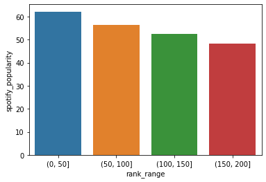

```python
# split the pitchfork list into 4 sections and get the average of each group
rank_ranges = [0, 50, 100, 150, 200]
pitchfork_data['rank_range'] = pd.cut(x=pitchfork_data['rank'], bins=rank_ranges)
rank_range_averages = pitchfork_data.groupby(['rank_range']).mean().reset_index()
sns.barplot(x='rank_range', y = 'spotify_popularity', data=rank_range_averages)
```

## Are Commercially Succesful Albums Critically Acclaimed?

### Billboard's list vs. Metascore

I started by looking at Pitchfork's data because I'm a frequent reader of their reviews, they review a lot of material, they have a large following, and also because their list was more extensive than Metacritic's. Metacritic, however, is an aggregator of critics' ratings of albums (amongst other things such as movies and video games) that weights scores from respected critics and normalizes them to a 0-100 range. As another method of comparing critical success to commercial success, we're going to scrape the aggregate scores of the albums on Billboard's top 200 best selling albums of the decade list. Metacritic does not offer an API and they also only have a score for albums which are reviewed at least 4 times by respected critics, so a fair bit of data may be missing, especially since lots of the Billboard list included soundtracks which not many critics review.

```python
for index, row in billboard_data.iterrows():
    encoded_artist = row['artist'].replace(' ', '+').lower()
    encoded_title = row['title'].replace(' ', '-').replace('\'', '').replace('.', '').lower()
    url = 'https://www.metacritic.com/music/' + encoded_title + '/' + encoded_artist
    r = requests.get(url, headers={"user-agent": "Mozilla/5.0 (Macintosh; Intel Mac OS X x.y; rv:42.0) Gecko/20100101 Firefox/42.0"})
    soup = BS(r.text)
    score_div = ''
    if soup.find('div', {'class' : 'metascore_w xlarge album positive'}) != None:
        score_div = soup.find('div', {'class' : 'metascore_w xlarge album positive'})
    elif soup.find('div', {'class' : 'metascore_w xlarge album mixed'}) != None:
        score_div = soup.find('div', {'class' : 'metascore_w xlarge album mixed'})
    elif soup.find('div', {'class' : 'metascore_w xlarge album negative'}) != None:
        score_div = soup.find('div', {'class' : 'metascore_w xlarge album negative'})
    if score_div:
        billboard_data.loc[index, 'metascore'] = float(score_div.find('span').text)
billboard_data
```

|  | rank | artist | title | metascore |
| --- | --- | --- | --- | --- |
| 0 | 1 | Adele | 21 | 76 |
| 1 | 2 | Taylor Swift | 1989 | 69 |
| 2 | 3 | Ed Sheeran | ÷ (Divide) | NaN |
| 3 | 4 | Soundtrack | Frozen | NaN |
| 4 | 5 | Post Malone | beerbongs & bentleys | NaN |
| ... | ... | ... | ... | ... |
| 195 | 196 | The Black Keys | Brothers | 82 |
| 196 | 197 | Various Artists | NOW 41 | NaN |
| 197 | 198 | Billie Eilish | Dont Smile At Me | NaN |
| 198 | 199 | J. Cole | Born Sinner | 71 |
| 199 | 200 | One Direction | FOUR | 65 |

200 rows × 4 columns

Now that we have the data, we can compare metascores to how well albums sold compared to other albums of the decade.

```python
billboard_data.plot.scatter(x='rank', y='metascore', hover_data=['artist', 'title'])
```

[interactive chart not shown]

While not neccesarily shocking, the difference between this graph comparing the critical reception of the top selling albums and the previous graph which compared the commercial popularity of critically acclaimed (by Pitchfork) albums is quite substantial. While a majority of the albums on Pitchfork's list were fairly popular by Spotify's metric, the best selling albums on Billboard's list are not all that critically successful.

## Tying it All Together

### Comparing the popularity of critically acclaimed albums to the critical reception of commercially succesful albums

The following graph shows the distribution of Spotify popularity scores of albums on Pitchfork's 200 best albums of the decade list. This graph illustrates the spread of popularity of critically acclaimed albums.

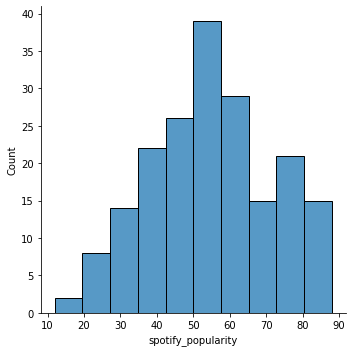

```python
sns.displot(x='spotify_popularity', data=pitchfork_data)
```

The next graph will show us the distribution of Metascores of albums on Billboard's top 200 selling albums of the decade.

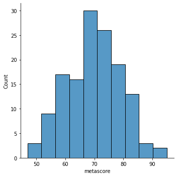

```python
sns.displot(x=billboard_data['metascore'])
```

So that there is some control data, I thought I'd show the metascore distribution of albums on Pitchfork's list. After all, we've been using their list as a sample of critically acclaimed albums with no true basis that it represents a good collection of critically acclaimed albums while we KNOW Billboard's list is backed by sales data. Let's prove that Pitchfork's list isn't disagreed with strongly by other critics and is indeed a good representation of the most well received albums of the decade.

```python
for index, row in pitchfork_data.iterrows():
    encoded_artist = row['artist'].replace(' ', '-').lower()
    encoded_title = row['title'].replace(' ', '-').replace('\'', '').replace('.', '').lower()
    url = 'https://www.metacritic.com/music/' + encoded_title + '/' + encoded_artist
    r = requests.get(url, headers={"user-agent": "Mozilla/5.0 (Macintosh; Intel Mac OS X x.y; rv:42.0) Gecko/20100101 Firefox/42.0"})
    soup = BS(r.text)
    score_div = ''
    if soup.find('div', {'class' : 'metascore_w xlarge album positive'}) != None:
        score_div = soup.find('div', {'class' : 'metascore_w xlarge album positive'})
    elif soup.find('div', {'class' : 'metascore_w xlarge album mixed'}) != None:
        score_div = soup.find('div', {'class' : 'metascore_w xlarge album mixed'})
    elif soup.find('div', {'class' : 'metascore_w xlarge album negative'}) != None:
        score_div = soup.find('div', {'class' : 'metascore_w xlarge album negative'})
    if score_div:
        pitchfork_data.loc[index, 'metascore'] = float(score_div.find('span').text)
```

```python
pitchfork_data[pitchfork_data['metascore'] > 0].plot.scatter(x='rank', y='metascore', hover_data=['artist', 'title'])
```

[interactive chart not shown]

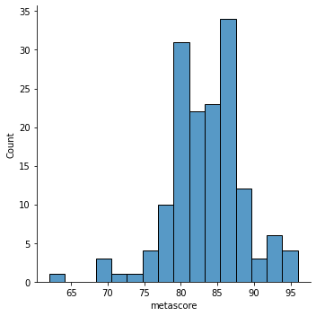

```python
sns.displot(x=pitchfork_data['metascore'])
```

Both of these graphs illustrate pretty strongly exactly what we've been assuming the whole time: Pitchfork's top 200 albums of the decade are held in very high regard by critics. Only a handful of albums have Metascores lower than 70 and that handful happens to be hip-hop albums which from personal experience I would guess is because Pitchfork tends to be more favorable of that genre than other publications are.

# Final Thoughts

After looking at lots of data, there's one sentence that I think can sum up what I've learned: **the most critically succesful albums tend to be popular, but popular albums aren't necessarily critically succesful**. This doesn't come as too much of a suprise to me. Mainstream music and songs or albums that get radio play are often not the genre or style of music that critics are handing out rave reviews to (the overlap of Pitchfork's and Billboard's list illustrated this), but the albums that critics do like are often still very popular just not the MOST popular or best selling.